# Basic Logging & Plotting with R

Struma

October 6, 2018

## Data logging and visualization - CSV files

If you are getting into electronics, you will no doubt consider making a data logger.

A simple data logger works by writing data (from sensors) to a file, usually one line at a time. Each single line by itself then contains all the datetimes, measurements, and relevant values to characterize a single moment in the life of the logger.

Most people write data to a text file in the form of a formatted list of values that are“column delimited” by a character, and “row delimited” by line.

The most common data list is a .CSV file. CSV stands for *comma seperated values* and indicates that the delimiter character that seperates fields is a “,”.

**A csv file will typically have column names listed in the first line as character strings in quotation marks as below.**

[figure not shown]

If there are column names in the first line of your file, mark the col_names option to TRUE when you read it into R.

### Starting with R

R is the one of the best open source programming language for practicing statistics and doing math. The language is vectorized and extremly clean with huge emphasis on grahic aesthetics as well as intuitive control. Download R, and then install “R studio IDE”" from cran!

links that go into detail

Install R (free online for everyone)

Install Rstudio IDE

Update

Install tidyverse

download the ggplot2 cheat sheet [“download”](https://www.rstudio.com/wp-content/uploads/2015/03/ggplot2-cheatsheet.pdf)

follow along

```r
library(tidyverse)  #all the packages that we need to import and visualize data

#now read in a csv. I called my csv "third".
third <- read_csv("/media/julio/HHD/HHD_projects/Sensor_orb/Light_logger_test/20181003.CSV", col_names = TRUE)
```

#### You might be inclined to plot the data right out of the box with no special changes. Sometimes it will work.

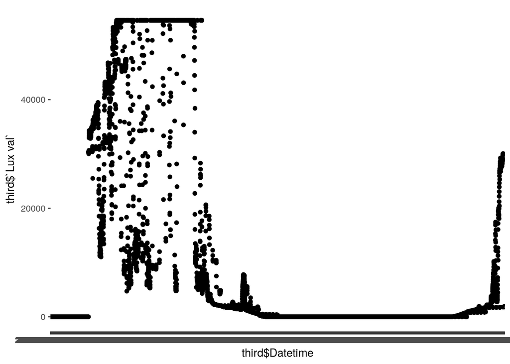

```r
ggplot(third, aes(x = third$Datetime, y=third$`Lux val`)) +
  geom_point()
```

But it doesn’t really work with this example…

That’s **because the datetime column is a character string.** YOU need to tell R that it should parse the string into a datetime object. Once a datetime object, R will put our data in calendar order!

```r
third_clean <- third %>%
  mutate(time =  as.POSIXct(strftime(third$Datetime)))
```

Nice!

#### Plot the data

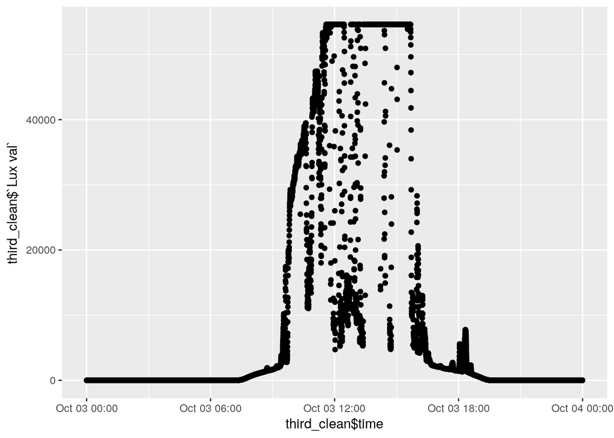

```r
ggplot(third_clean, aes(x = third_clean$time, y = third_clean$`Lux val`)) +
  geom_point()
```

#### This plot is now correct. We can tell intuitavly that this is right, because the graph is in the shape we ould expect if we logged light from 12am to 12am.

Now that we have a basic graph, we can do basic formatting

#### First we can make our scale in terms of hours using ggplot’s scale_x_datetime() function.

I used %H as the formatter in this example because it gives hours in 24hr format. %I will yeild a 12hr format. %a will give day of week. I found these marks by reading the documentation for dates and times.

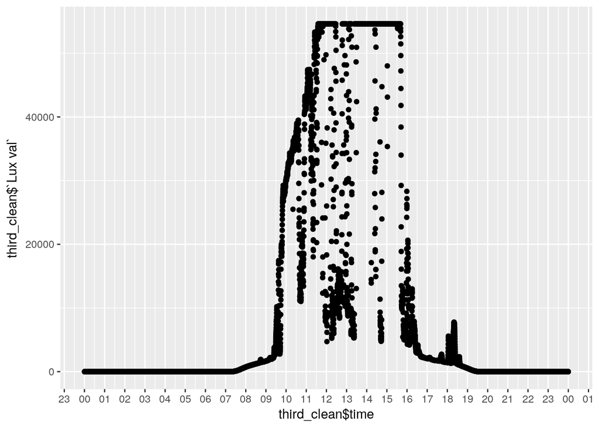

```r
ggplot(third_clean, aes(x = third_clean$time, y = third_clean$`Lux val`)) +
  geom_point() +
  scale_x_datetime(date_breaks = "1 hour", date_labels = "%H")
```

#### Fix the y axis, lets see it in divisions of 10,000 Lux, starting at 5,000 lux

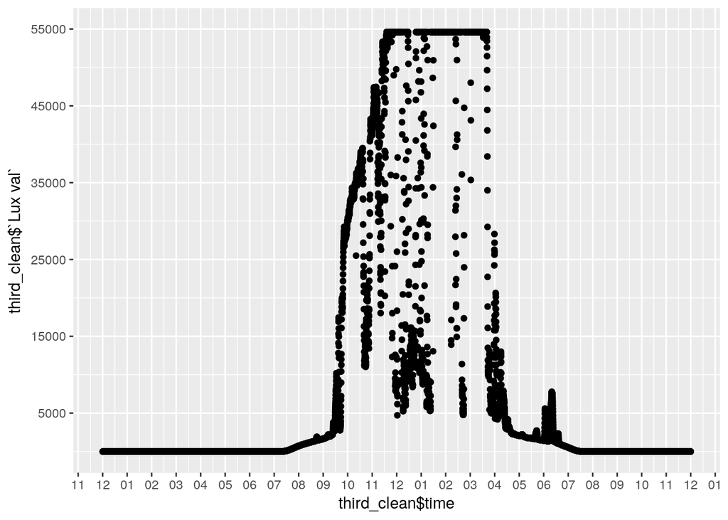

```r
ggplot(third_clean, aes(x = third_clean$time, y = third_clean$`Lux val`)) +
  geom_point() +
  scale_x_datetime(date_breaks = "1 hour", date_labels = "%I")+
  scale_y_continuous(limits = c(0,55000), breaks = seq(5000,55000, 10000))
```